# Project: Wrangling and Analyze Data

## import packages necessary

```python
import tweepy
import pandas as pd
import numpy as np
from tweepy import OAuthHandler
import json
import matplotlib.pyplot as plt
import os
import requests
import pandas as pd
import sys
import seaborn as sns
from datetime import datetime
from timeit import default_timer as timer
%matplotlib inline

#set long text
pd.options.display.max_colwidth= 255
```

### Setting of keys and other tools that allow us to communicate with the tweet api

```python
consumer_key = ' hidden'
consumer_secret = 'hidden'
access_token = 'hidden'
access_secret = 'hidden'
#
auth = OAuthHandler(consumer_key, consumer_secret)
auth.set_access_token(access_token, access_secret)


api = tweepy.API(auth, wait_on_rate_limit=True)
```

## Data Gathering

Directly download the WeRateDogs Twitter archive data (twitter_archive_enhanced.csv)

```python
df_archive_enhanced = pd.read_csv('twitter-archive-enhanced.csv')
```

```python
df_archive_enhanced.sample(2)
```

|  | tweet_id | in_reply_to_status_id | in_reply_to_user_id | timestamp | source | text | retweeted_status_id | retweeted_status_user_id | retweeted_status_timestamp | expanded_urls | rating_numerator | rating_denominator | name | doggo | floofer | pupper | puppo |
| --- | --- | --- | --- | --- | --- | --- | --- | --- | --- | --- | --- | --- | --- | --- | --- | --- | --- |
| 378 | 827933404142436356 | NaN | NaN | 2017-02-04 17:34:40 +0000 | <a href="http://twitter.com/download/iphone" rel="nofollow">Twitter for iPhone</a> | This is Kona. Yesterday she stopped by the department to see what it takes to be a police pupper. 12/10 vest was only a smidge too big https://t.co/j8D3PQJvpJ | NaN | NaN | NaN | https://twitter.com/dog_rates/status/827933404142436356/photo/1,https://twitter.com/dog_rates/status/827933404142436356/photo/1,https://twitter.com/dog_rates/status/827933404142436356/photo/1 | 12 | 10 | Kona | None | None | pupper | None |
| 793 | 773547596996571136 | NaN | NaN | 2016-09-07 15:44:53 +0000 | <a href="http://twitter.com/download/iphone" rel="nofollow">Twitter for iPhone</a> | This is Chelsea. She forgot how to dog. 11/10 get it together pupper https://t.co/nBJ5RE4yHb | NaN | NaN | NaN | https://twitter.com/dog_rates/status/773547596996571136/photo/1 | 11 | 10 | Chelsea | None | None | pupper | None |

Query Twitter API for each tweet in the Twitter archive and save JSON in a text file These are hidden to comply with Twitter's API terms and conditions

```python
#get all id of old tweets
#tweet_ids = df_archive_enhanced.tweet_id.values
#len(tweet_ids)
# Query Twitter's API for JSON data for each tweet ID in the Twitter archive
#count = 0

#fails_dict = {}
#start = timer()
# Save each tweet's returned JSON as a new line in a .txt file

#with open('tweet_json.txt', 'w') as outfile:
    # This loop will likely take 20-30 minutes to run because of Twitter's rate limit
     #for tweet_id in tweet_ids:
        #count += 1
        #print(str(count) + ": " + str(tweet_id))
        #try:
            #tweet = api.get_status(tweet_id, tweet_mode='extended')
            #print("Success")
            #json.dump(tweet._json, outfile)
            #outfile.write('\n')
        #except Exception as e:
            #print("Fail")
            #fails_dict[tweet_id] = e
            #pass
        #break
#end = timer()
#print(end - start)
#print(fails_dict)
```

### Use of the second method, that consists of downloading manually the text-json.txt

```python
tweets = []
tweets_sorted = []
#feaching data from txtJson file line by line
for line in open('tweet-json.txt', 'r'):
    tweets.append(json.loads(line))
```

1. Use the Requests library to download the tweet image prediction (image_predictions.tsv)

```python
# For more precaution, let's fetch url, if the file doesn't exist
file_prediction_image='image-predictions.tsv'
if not os.path.isfile(file_prediction_image):
    url_img = 'https://d17h27t6h515a5.cloudfront.net/topher/2017/August/599fd2ad_image-predictions/image-predictions.tsv'

    #store the the image found from the above url
    response = requests.get(url_img)
```

```python
if not os.path.isfile(file_prediction_image):
    #open wb as binary, because they are images
    with open(file_name, mode ='wb') as file:
        #we store the content into the file
        file.write(reponse.content)
```

```python
#store the file content into a dataframe
#the sep = '\t', helps to create tabulation in creating prediction's dataframe

df_prediction_image = pd.read_csv(file_prediction_image, sep='\t')
df_prediction_image.sample(3)
```

|  | tweet_id | jpg_url | img_num | p1 | p1_conf | p1_dog | p2 | p2_conf | p2_dog | p3 | p3_conf | p3_dog |
| --- | --- | --- | --- | --- | --- | --- | --- | --- | --- | --- | --- | --- |
| 48 | 666826780179869698 | https://pbs.twimg.com/media/CUELa0NUkAAscGC.jpg | 1 | Maltese_dog | 0.359383 | True | teddy | 0.148759 | False | West_Highland_white_terrier | 0.106007 | True |
| 1885 | 847842811428974592 | https://pbs.twimg.com/media/C8QkidrVYAQXQh7.jpg | 1 | Bernese_mountain_dog | 0.951337 | True | Greater_Swiss_Mountain_dog | 0.016849 | True | Appenzeller | 0.010849 | True |
| 1628 | 804738756058218496 | https://pbs.twimg.com/media/CysBn-lWIAAoRx1.jpg | 1 | Tibetan_mastiff | 0.915790 | True | German_shepherd | 0.062480 | True | Leonberg | 0.008297 | True |

1. Use the Tweepy library to query additional data via the Twitter API (tweet_json.txt)

```python
#retreive it from the list
for tweet in tweets:
        #select the important data
        tweets_sorted.append({'tweet_id': tweet['id'],
                        'retweet_count': tweet['retweet_count'],
                        'favorite_count': tweet['favorite_count'],
                        'followers_count': tweet['user']['followers_count']})
df_tweets_additionnal = pd.DataFrame(tweets_sorted)
```

```python
df_tweets_additionnal.head()
```

|  | tweet_id | retweet_count | favorite_count | followers_count |
| --- | --- | --- | --- | --- |
| 0 | 892420643555336193 | 8853 | 39467 | 3200889 |
| 1 | 892177421306343426 | 6514 | 33819 | 3200889 |
| 2 | 891815181378084864 | 4328 | 25461 | 3200889 |
| 3 | 891689557279858688 | 8964 | 42908 | 3200889 |
| 4 | 891327558926688256 | 9774 | 41048 | 3200889 |

## Quality of the dataset concerned

### First : Assessing of the old dataset of The WateRatedogs named : df_archive_enhanced

```python
#let'us explore it
df_archive_enhanced.sample(5)
```

|  | tweet_id | in_reply_to_status_id | in_reply_to_user_id | timestamp | source | text | retweeted_status_id | retweeted_status_user_id | retweeted_status_timestamp | expanded_urls | rating_numerator | rating_denominator | name | doggo | floofer | pupper | puppo |
| --- | --- | --- | --- | --- | --- | --- | --- | --- | --- | --- | --- | --- | --- | --- | --- | --- | --- |
| 48 | 882992080364220416 | NaN | NaN | 2017-07-06 15:58:11 +0000 | <a href="http://twitter.com/download/iphone" rel="nofollow">Twitter for iPhone</a> | This is Rusty. He wasn't ready for the first pic. Clearly puppared for the second. 13/10 confirmed great boy https://t.co/tyER0KpdXj | NaN | NaN | NaN | https://twitter.com/dog_rates/status/882992080364220416/photo/1,https://twitter.com/dog_rates/status/882992080364220416/photo/1 | 13 | 10 | Rusty | None | None | None | None |
| 937 | 753298634498793472 | NaN | NaN | 2016-07-13 18:42:44 +0000 | <a href="http://twitter.com/download/iphone" rel="nofollow">Twitter for iPhone</a> | RT @dog_rates: This is Carly. She's actually 2 dogs fused together. Very innovative. Probably has superpowers. 12/10 for double dog https:/… | 6.815232e+17 | 4.196984e+09 | 2015-12-28 17:12:42 +0000 | https://twitter.com/dog_rates/status/681523177663676416/photo/1 | 12 | 10 | Carly | None | None | None | None |
| 1530 | 690021994562220032 | NaN | NaN | 2016-01-21 04:03:58 +0000 | <a href="http://twitter.com/download/iphone" rel="nofollow">Twitter for iPhone</a> | Say hello to Geoff (pronounced "Kyle"). He accidentally opened the front facing camera. 10/10 https://t.co/TmlwQWnmRC | NaN | NaN | NaN | https://twitter.com/dog_rates/status/690021994562220032/photo/1 | 10 | 10 | Geoff | None | None | None | None |
| 700 | 786233965241827333 | NaN | NaN | 2016-10-12 15:55:59 +0000 | <a href="http://twitter.com/download/iphone" rel="nofollow">Twitter for iPhone</a> | This is Mattie. She's extremely dangerous. Will bite your h*ckin finger right off. Still 11/10 would pet with caution https://t.co/78c9W8kLFh | NaN | NaN | NaN | https://twitter.com/dog_rates/status/786233965241827333/photo/1 | 11 | 10 | Mattie | None | None | None | None |
| 2352 | 666044226329800704 | NaN | NaN | 2015-11-16 00:04:52 +0000 | <a href="http://twitter.com/download/iphone" rel="nofollow">Twitter for iPhone</a> | This is a purebred Piers Morgan. Loves to Netflix and chill. Always looks like he forgot to unplug the iron. 6/10 https://t.co/DWnyCjf2mx | NaN | NaN | NaN | https://twitter.com/dog_rates/status/666044226329800704/photo/1 | 6 | 10 | a | None | None | None | None |

### Before analyse it, let us make a bit explanation about all columns that interests this project

- tweet_id : represents the primary key of every tweet;
- timestamp : UTC time when this Tweet was created, it's called also created_at on tweet object
- source : is the url link (href) that allows user the post of the tweet;
- text : is message found inside of the tweet
- rating_numerator : Dog numerator rate
- raiting_denominator : Dog denominator rate
- name : represents the name of the dog
- doggo, floofer, pupper, puppo, are chronological dog personnality

### Observation :

- The doggo, flooter, pupper, puppo should be in the same column
- The source variable contains invalids url

```python
#Gettting acquainted to data with info method
df_archive_enhanced.info()
```

```
<class 'pandas.core.frame.DataFrame'>
RangeIndex: 2356 entries, 0 to 2355
Data columns (total 17 columns):
 #   Column                      Non-Null Count  Dtype
---  ------                      --------------  -----
 0   tweet_id                    2356 non-null   int64
 1   in_reply_to_status_id       78 non-null     float64
 2   in_reply_to_user_id         78 non-null     float64
 3   timestamp                   2356 non-null   object
 4   source                      2356 non-null   object
 5   text                        2356 non-null   object
 6   retweeted_status_id         181 non-null    float64
 7   retweeted_status_user_id    181 non-null    float64
 8   retweeted_status_timestamp  181 non-null    object
 9   expanded_urls               2297 non-null   object
 10  rating_numerator            2356 non-null   int64
 11  rating_denominator          2356 non-null   int64
 12  name                        2356 non-null   object
 13  doggo                       2356 non-null   object
 14  floofer                     2356 non-null   object
 15  pupper                      2356 non-null   object
 16  puppo                       2356 non-null   object
dtypes: float64(4), int64(3), object(10)
memory usage: 313.0+ KB
```

### Observation:

- doggo, flooter, pupper, puppo have some entries which contain none instead of NAN
- completeness issue : we should have 5000 tweets or more than it, but we've 2356 entries only
- timestamp variable is object, related to string, whereas it must have datetime format : validity issue

```python
sum(df_archive_enhanced['expanded_urls'].isnull())
```

```
59
```

```python
df_archive_enhanced['expanded_urls'].sample(10).T
```

```
723                                                                                                                                    https://twitter.com/dog_rates/status/782969140009107456/photo/1,https://twitter.com/dog_rates/status/782969140009107456/photo/1
1000                                                                                                                                                                                                   https://twitter.com/dog_rates/status/747963614829678593/photo/1
1806                                                                                                                                                                                                   https://twitter.com/dog_rates/status/676936541936185344/photo/1
1020                                                                                                                                                                                                                                     https://vine.co/v/5BYq6hmrEI3
1267                                                                                                                                                                                                   https://twitter.com/dog_rates/status/709566166965075968/photo/1
1413                                                                   https://twitter.com/dog_rates/status/698907974262222848/photo/1,https://twitter.com/dog_rates/status/698907974262222848/photo/1,https://twitter.com/dog_rates/status/698907974262222848/photo/1
1015    https://twitter.com/dog_rates/status/747103485104099331/photo/1,https://twitter.com/dog_rates/status/747103485104099331/photo/1,https://twitter.com/dog_rates/status/747103485104099331/photo/1,https://twitter.com/dog_rates/status/747103485104099331/pho...
2257                                                                                                                                                                                                   https://twitter.com/dog_rates/status/667728196545200128/photo/1
131                                                                                                                                                                                                    https://twitter.com/dog_rates/status/867051520902168576/photo/1
93                                                                                                                                                                                                     https://twitter.com/dog_rates/status/874057562936811520/photo/1
Name: expanded_urls, dtype: object
```

```python
#check the number of entries that contains double links
print(df_archive_enhanced['expanded_urls'].str.contains(',').sum())
```

```
639
```

##### Observation : 639 expanded_urls contains double links

```python
#Account of tweet_id
sum(df_archive_enhanced['tweet_id'].duplicated())
```

```
0
```

```python
#entries whose rating_numerator is less than or equal to 0
print('we have {} entries whose rating_numerator is less than 10:'.format(df_archive_enhanced[df_archive_enhanced['rating_numerator'] < 10].shape[0]))
#Here is the conerned entrie
```

```
we have 440 entries whose rating_numerator is less than 10:
```

```python
df_archive_enhanced[df_archive_enhanced['rating_numerator'] < 10].T
```

|  | 45 | 229 | 315 | 387 | 462 | 485 | 599 | 605 | 730 | 745 | ... | 2342 | 2344 | 2346 | 2347 | 2349 | 2351 | 2352 | 2353 | 2354 | 2355 |
| --- | --- | --- | --- | --- | --- | --- | --- | --- | --- | --- | --- | --- | --- | --- | --- | --- | --- | --- | --- | --- | --- |
| tweet_id | 883482846933004288 | 848212111729840128 | 835152434251116546 | 826598799820865537 | 817502432452313088 | 814578408554463233 | 798682547630837760 | 798576900688019456 | 781661882474196992 | 780092040432480260 | ... | 666082916733198337 | 666071193221509120 | 666058600524156928 | 666057090499244032 | 666051853826850816 | 666049248165822465 | 666044226329800704 | 666033412701032449 | 666029285002620928 | 666020888022790149 |
| in_reply_to_status_id | NaN | NaN | NaN | 826598365270007808.0 | NaN | NaN | NaN | NaN | NaN | NaN | ... | NaN | NaN | NaN | NaN | NaN | NaN | NaN | NaN | NaN | NaN |
| in_reply_to_user_id | NaN | NaN | NaN | 4196983835.0 | NaN | NaN | NaN | NaN | NaN | NaN | ... | NaN | NaN | NaN | NaN | NaN | NaN | NaN | NaN | NaN | NaN |
| timestamp | 2017-07-08 00:28:19 +0000 | 2017-04-01 16:35:01 +0000 | 2017-02-24 15:40:31 +0000 | 2017-02-01 01:11:25 +0000 | 2017-01-06 22:45:43 +0000 | 2016-12-29 21:06:41 +0000 | 2016-11-16 00:22:12 +0000 | 2016-11-15 17:22:24 +0000 | 2016-09-30 01:08:10 +0000 | 2016-09-25 17:10:10 +0000 | ... | 2015-11-16 02:38:37 +0000 | 2015-11-16 01:52:02 +0000 | 2015-11-16 01:01:59 +0000 | 2015-11-16 00:55:59 +0000 | 2015-11-16 00:35:11 +0000 | 2015-11-16 00:24:50 +0000 | 2015-11-16 00:04:52 +0000 | 2015-11-15 23:21:54 +0000 | 2015-11-15 23:05:30 +0000 | 2015-11-15 22:32:08 +0000 |
| source | <a href="http://twitter.com/download/iphone" rel="nofollow">Twitter for iPhone</a> | <a href="http://twitter.com/download/iphone" rel="nofollow">Twitter for iPhone</a> | <a href="http://twitter.com/download/iphone" rel="nofollow">Twitter for iPhone</a> | <a href="http://twitter.com/download/iphone" rel="nofollow">Twitter for iPhone</a> | <a href="http://twitter.com/download/iphone" rel="nofollow">Twitter for iPhone</a> | <a href="http://twitter.com/download/iphone" rel="nofollow">Twitter for iPhone</a> | <a href="http://twitter.com/download/iphone" rel="nofollow">Twitter for iPhone</a> | <a href="http://twitter.com/download/iphone" rel="nofollow">Twitter for iPhone</a> | <a href="http://twitter.com/download/iphone" rel="nofollow">Twitter for iPhone</a> | <a href="http://twitter.com/download/iphone" rel="nofollow">Twitter for iPhone</a> | ... | <a href="http://twitter.com/download/iphone" rel="nofollow">Twitter for iPhone</a> | <a href="http://twitter.com/download/iphone" rel="nofollow">Twitter for iPhone</a> | <a href="http://twitter.com/download/iphone" rel="nofollow">Twitter for iPhone</a> | <a href="http://twitter.com/download/iphone" rel="nofollow">Twitter for iPhone</a> | <a href="http://twitter.com/download/iphone" rel="nofollow">Twitter for iPhone</a> | <a href="http://twitter.com/download/iphone" rel="nofollow">Twitter for iPhone</a> | <a href="http://twitter.com/download/iphone" rel="nofollow">Twitter for iPhone</a> | <a href="http://twitter.com/download/iphone" rel="nofollow">Twitter for iPhone</a> | <a href="http://twitter.com/download/iphone" rel="nofollow">Twitter for iPhone</a> | <a href="http://twitter.com/download/iphone" rel="nofollow">Twitter for iPhone</a> |
| text | This is Bella. She hopes her smile made you smile. If not, she is also offering you her favorite monkey. 13.5/10 https://t.co/qjrljjt948 | This is Jerry. He's doing a distinguished tongue slip. Slightly patronizing tbh. You think you're better than us, Jerry? 6/10 hold me back https://t.co/DkOBbwulw1 | When you're so blinded by your systematic plagiarism that you forget what day it is. 0/10 https://t.co/YbEJPkg4Ag | I was going to do 007/10, but the joke wasn't worth the &lt;10 rating | RT @dog_rates: Meet Herschel. He's slightly bigger than ur average pupper. Looks lonely. Could probably ride 7/10 would totally pet https:/… | RT @dog_rates: Meet Beau &amp; Wilbur. Wilbur stole Beau's bed from him. Wilbur now has so much room for activities. 9/10 for both pups https:/… | RT @dog_rates: Here we see a rare pouched pupper. Ample storage space. Looks alert. Jumps at random. Kicked open that door. 8/10 https://t.… | RT @dog_rates: Not familiar with this breed. No tail (weird). Only 2 legs. Doesn't bark. Surprisingly quick. Shits eggs. 1/10 https://t.co/… | Who keeps sending in pictures without dogs in them? This needs to stop. 5/10 for the mediocre road https://t.co/ELqelxWMrC | RT @dog_rates: This is Hank. He's mischievous af. Doesn't even know what he was trying to do here. 8/10 quit the shit Hank damn https://t.c… | ... | Here we have a well-established sunblockerspaniel. Lost his other flip-flop. 6/10 not very waterproof https://t.co/3RU6x0vHB7 | Here we have a northern speckled Rhododendron. Much sass. Gives 0 fucks. Good tongue. 9/10 would caress sensually https://t.co/ZoL8kq2XFx | Here is the Rand Paul of retrievers folks! He's probably good at poker. Can drink beer (lol rad). 8/10 good dog https://t.co/pYAJkAe76p | My oh my. This is a rare blond Canadian terrier on wheels. Only $8.98. Rather docile. 9/10 very rare https://t.co/yWBqbrzy8O | This is an odd dog. Hard on the outside but loving on the inside. Petting still fun. Doesn't play catch well. 2/10 https://t.co/v5A4vzSDdc | Here we have a 1949 1st generation vulpix. Enjoys sweat tea and Fox News. Cannot be phased. 5/10 https://t.co/4B7cOc1EDq | This is a purebred Piers Morgan. Loves to Netflix and chill. Always looks like he forgot to unplug the iron. 6/10 https://t.co/DWnyCjf2mx | Here is a very happy pup. Big fan of well-maintained decks. Just look at that tongue. 9/10 would cuddle af https://t.co/y671yMhoiR | This is a western brown Mitsubishi terrier. Upset about leaf. Actually 2 dogs here. 7/10 would walk the shit out of https://t.co/r7mOb2m0UI | Here we have a Japanese Irish Setter. Lost eye in Vietnam (?). Big fan of relaxing on stair. 8/10 would pet https://t.co/BLDqew2Ijj |
| retweeted_status_id | NaN | NaN | NaN | NaN | 692417313023332352.0 | 698195409219559424.0 | 676936541936185344.0 | 666104133288665088.0 | NaN | 753375668877008896.0 | ... | NaN | NaN | NaN | NaN | NaN | NaN | NaN | NaN | NaN | NaN |
| retweeted_status_user_id | NaN | NaN | NaN | NaN | 4196983835.0 | 4196983835.0 | 4196983835.0 | 4196983835.0 | NaN | 4196983835.0 | ... | NaN | NaN | NaN | NaN | NaN | NaN | NaN | NaN | NaN | NaN |
| retweeted_status_timestamp | NaN | NaN | NaN | NaN | 2016-01-27 18:42:06 +0000 | 2016-02-12 17:22:12 +0000 | 2015-12-16 01:27:03 +0000 | 2015-11-16 04:02:55 +0000 | NaN | 2016-07-13 23:48:51 +0000 | ... | NaN | NaN | NaN | NaN | NaN | NaN | NaN | NaN | NaN | NaN |
| expanded_urls | https://twitter.com/dog_rates/status/883482846933004288/photo/1,https://twitter.com/dog_rates/status/883482846933004288/photo/1 | https://twitter.com/dog_rates/status/848212111729840128/photo/1 | https://twitter.com/dog_rates/status/835152434251116546/photo/1,https://twitter.com/dog_rates/status/835152434251116546/photo/1,https://twitter.com/dog_rates/status/835152434251116546/photo/1 | NaN | https://twitter.com/dog_rates/status/692417313023332352/photo/1 | https://twitter.com/dog_rates/status/698195409219559425/photo/1 | https://twitter.com/dog_rates/status/676936541936185344/photo/1 | https://twitter.com/dog_rates/status/666104133288665088/photo/1 | https://twitter.com/dog_rates/status/781661882474196992/photo/1 | https://twitter.com/dog_rates/status/753375668877008896/photo/1 | ... | https://twitter.com/dog_rates/status/666082916733198337/photo/1 | https://twitter.com/dog_rates/status/666071193221509120/photo/1 | https://twitter.com/dog_rates/status/666058600524156928/photo/1 | https://twitter.com/dog_rates/status/666057090499244032/photo/1 | https://twitter.com/dog_rates/status/666051853826850816/photo/1 | https://twitter.com/dog_rates/status/666049248165822465/photo/1 | https://twitter.com/dog_rates/status/666044226329800704/photo/1 | https://twitter.com/dog_rates/status/666033412701032449/photo/1 | https://twitter.com/dog_rates/status/666029285002620928/photo/1 | https://twitter.com/dog_rates/status/666020888022790149/photo/1 |
| rating_numerator | 5 | 6 | 0 | 7 | 7 | 9 | 8 | 1 | 5 | 8 | ... | 6 | 9 | 8 | 9 | 2 | 5 | 6 | 9 | 7 | 8 |
| rating_denominator | 10 | 10 | 10 | 10 | 10 | 10 | 10 | 10 | 10 | 10 | ... | 10 | 10 | 10 | 10 | 10 | 10 | 10 | 10 | 10 | 10 |
| name | Bella | Jerry | None | None | Herschel | Beau | None | None | None | Hank | ... | None | None | the | a | an | None | a | a | a | None |
| doggo | None | None | None | None | None | None | None | None | None | None | ... | None | None | None | None | None | None | None | None | None | None |
| floofer | None | None | None | None | None | None | None | None | None | None | ... | None | None | None | None | None | None | None | None | None | None |
| pupper | None | None | None | None | pupper | None | pupper | None | None | None | ... | None | None | None | None | None | None | None | None | None | None |
| puppo | None | None | None | None | None | None | None | None | None | None | ... | None | None | None | None | None | None | None | None | None | None |

17 rows × 440 columns

[figure not shown]

```python
#Let'stand out this value by a visualisation with seaborn graphic
plt.figure(figsize =(15,7))
ax = sns.countplot(x=df_archive_enhanced.rating_numerator)
ax.set(ylabel = 'Tweets accounted', xlabel = 'rating_numerator')
plt.title('visualisation of dog rating_denominator')
```

```python
#entries whose rating_numerator is less than or equal to 0
print('we have {} entries whose rating_denominator is less than 10 '.format(df_archive_enhanced[df_archive_enhanced['rating_denominator'] < 10].shape[0]))
#Here is the conerned entrie
df_archive_enhanced[df_archive_enhanced['rating_denominator'] < 10].T
```

```
we have 3 entries whose rating_denominator is less than 10
```

|  | 313 | 516 | 2335 |
| --- | --- | --- | --- |
| tweet_id | 835246439529840640 | 810984652412424192 | 666287406224695296 |
| in_reply_to_status_id | 835245984028504064.0 | NaN | NaN |
| in_reply_to_user_id | 26259576.0 | NaN | NaN |
| timestamp | 2017-02-24 21:54:03 +0000 | 2016-12-19 23:06:23 +0000 | 2015-11-16 16:11:11 +0000 |
| source | <a href="http://twitter.com/download/iphone" rel="nofollow">Twitter for iPhone</a> | <a href="http://twitter.com/download/iphone" rel="nofollow">Twitter for iPhone</a> | <a href="http://twitter.com/download/iphone" rel="nofollow">Twitter for iPhone</a> |
| text | @jonnysun @Lin_Manuel ok jomny I know you're excited but 960/00 isn't a valid rating, 13/10 is tho | Meet Sam. She smiles 24/7 &amp; secretly aspires to be a reindeer. \nKeep Sam smiling by clicking and sharing this link:\nhttps://t.co/98tB8y7y7t https://t.co/LouL5vdvxx | This is an Albanian 3 1/2 legged Episcopalian. Loves well-polished hardwood flooring. Penis on the collar. 9/10 https://t.co/d9NcXFKwLv |
| retweeted_status_id | NaN | NaN | NaN |
| retweeted_status_user_id | NaN | NaN | NaN |
| retweeted_status_timestamp | NaN | NaN | NaN |
| expanded_urls | NaN | https://www.gofundme.com/sams-smile,https://twitter.com/dog_rates/status/810984652412424192/photo/1 | https://twitter.com/dog_rates/status/666287406224695296/photo/1 |
| rating_numerator | 960 | 24 | 1 |
| rating_denominator | 0 | 7 | 2 |
| name | None | Sam | an |
| doggo | None | None | None |
| floofer | None | None | None |
| pupper | None | None | None |
| puppo | None | None | None |

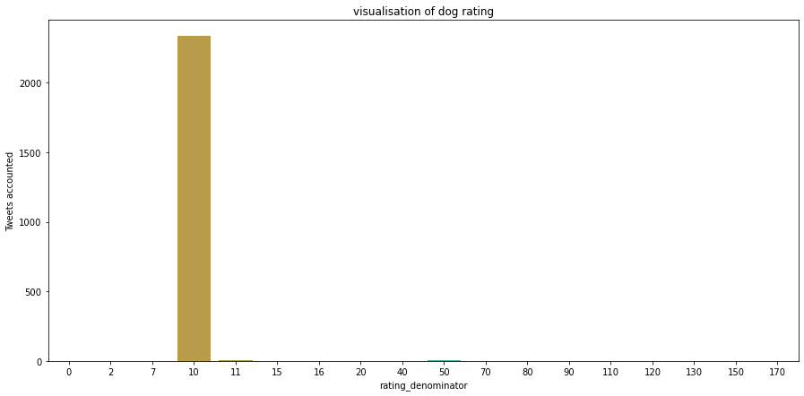

```python
#Let'stand out this value by a visualisation with seaborn graphic
plt.figure(figsize =(15,7))
ax = sns.countplot(x=df_archive_enhanced.rating_denominator)
ax.set(ylabel = 'Tweets accounted', xlabel = 'rating_denominator')
plt.title('visualisation of dog rating')
```

As we can seee, rating_denominotor is equal to 10 in majority

```python
#function that return the number of None entries in variables
def noneValueInColomn(dataFrame, nameColumn):
    count=0
    for entrie in dataFrame:
        if(entrie=='None'):
            count += 1
    if(count >0):
        print('{} entries found,  where the variable {} present a none value'.format(count, nameColumn))
    return count
```

```python
#Count none value in every column of df_archive_enhanced
countNone = 0
for column in df_archive_enhanced:
    countNone += noneValueInColomn(df_archive_enhanced[column],column)

print('\n We have in total {} none values for the dog personality'.format(countNone))
```

```
745 entries found,  where the variable name present a none value
2259 entries found,  where the variable doggo present a none value
2346 entries found,  where the variable floofer present a none value
2099 entries found,  where the variable pupper present a none value
2326 entries found,  where the variable puppo present a none value

 We have in total 9775 none values for the dog personality
```

## Secondly : Assessing of the tweet image predictions dataset intitled " df_prediction_image"

```python
df_prediction_image.sample(4)
```

|  | tweet_id | jpg_url | img_num | p1 | p1_conf | p1_dog | p2 | p2_conf | p2_dog | p3 | p3_conf | p3_dog |
| --- | --- | --- | --- | --- | --- | --- | --- | --- | --- | --- | --- | --- |
| 1083 | 718460005985447936 | https://pbs.twimg.com/media/Cfh7j6CWQAAndTd.jpg | 1 | badger | 0.356946 | False | Boston_bull | 0.252781 | True | kelpie | 0.113433 | True |
| 440 | 674447403907457024 | https://pbs.twimg.com/media/CVweVUfW4AACPwI.jpg | 1 | Brabancon_griffon | 0.409909 | True | malinois | 0.244649 | True | bull_mastiff | 0.074819 | True |
| 945 | 704480331685040129 | https://pbs.twimg.com/media/CcbRIAgXIAQaKHQ.jpg | 1 | Samoyed | 0.979206 | True | Pomeranian | 0.007185 | True | Arctic_fox | 0.006438 | False |
| 1476 | 780496263422808064 | https://pbs.twimg.com/media/Ck2d7tJWUAEPTL3.jpg | 1 | pug | 0.997310 | True | Brabancon_griffon | 0.001186 | True | French_bulldog | 0.000428 | True |

#### Let us as we have done for the first dataset, describing all variables most concerned by our assessing :

- tweet_id : primary key of every tweet
- jpg_url : image url of te dog
- p1 : variable that represents the first result of prediction
- p1_dog : a bool variable, witch is true if the dog is for the race
- p1_conf : certainly percent of p1
- Likewise for p2, p3 and p2_conf, p3_conf
- img_num : represents the number of the image

```python
df_prediction_image.info()
```

```
<class 'pandas.core.frame.DataFrame'>
RangeIndex: 2075 entries, 0 to 2074
Data columns (total 12 columns):
 #   Column    Non-Null Count  Dtype
---  ------    --------------  -----
 0   tweet_id  2075 non-null   int64
 1   jpg_url   2075 non-null   object
 2   img_num   2075 non-null   int64
 3   p1        2075 non-null   object
 4   p1_conf   2075 non-null   float64
 5   p1_dog    2075 non-null   bool
 6   p2        2075 non-null   object
 7   p2_conf   2075 non-null   float64
 8   p2_dog    2075 non-null   bool
 9   p3        2075 non-null   object
 10  p3_conf   2075 non-null   float64
 11  p3_dog    2075 non-null   bool
dtypes: bool(3), float64(3), int64(2), object(4)
memory usage: 152.1+ KB
```

```python
print('We have redundants {} entries'.format(df_prediction_image.duplicated().sum()))
```

```
We have redundants 0 entries
```

```python
print('We have redundants {} entries'.format(df_prediction_image.duplicated().sum()))
```

```
We have redundants 0 entries
```

```python
print('we have {} image whose numero is less than 1'.format(df_prediction_image[df_prediction_image['img_num']<1].shape[0]))
```

```
we have 0 image whose numero is less than 1
```

```python
#function for setting the size of figure
def figure_resize(f, w, h):
    f.set_figwidth(w)
    f.set_figheight(h)
df_prediction_image['img_num'].value_counts()
```

```
1    1780
2     198
3      66
4      31
Name: img_num, dtype: int64
```

```python
#Let us check the dog's race with his prediction's result
def dogPrediction(dataframe_dog, title) :
    plt.figure(figsize=(10,5))
    sns.countplot(x= dataframe_dog)
    ax.set(xlabel = 'value', ylabel='Numbers of image')
    plt.title(title)
    plt.show()
```

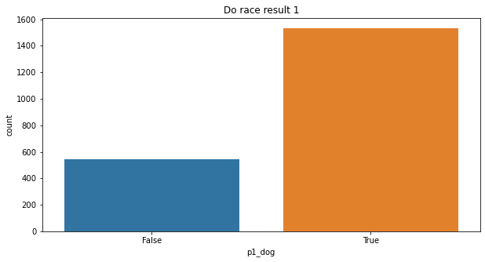

```python
#Let us check the first dog's race with his prediction's result
title ="Do race result 1"
dogPrediction(df_prediction_image.p1_dog,title)
```

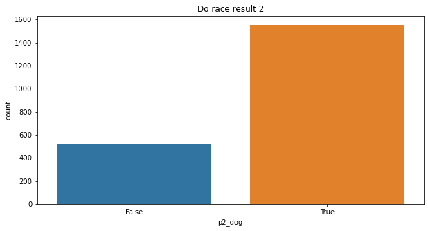

```python
#Let us check the second dog's race with his prediction's result
title ="Do race result 2"
dogPrediction(df_prediction_image.p2_dog,title)
```

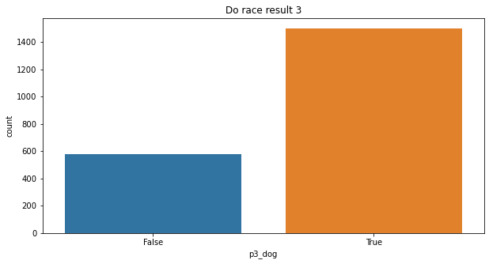

```python
#Let us check the second dog's race with his prediction's result
title ="Do race result 3"
dogPrediction(df_prediction_image.p3_dog,title)
```

```python
df_tweets_additionnal.sample(2)
```

|  | tweet_id | retweet_count | favorite_count | followers_count |
| --- | --- | --- | --- | --- |
| 1330 | 705475953783398401 | 1045 | 3231 | 3200947 |
| 1691 | 681297372102656000 | 1091 | 3490 | 3200952 |

Describing of all variables concerned by our assessing :

- tweet_id : primary key of every tweet
- retweet_count : represents how often the tweet has been retweeted
- favorite_count : Indicates approximately how many times the tweet has been liked by Twitter users
- followers_count : depictes the number of followers the user account of the tweet's creator has currently

```python
df_tweets_additionnal.info()
```

```
<class 'pandas.core.frame.DataFrame'>
RangeIndex: 2354 entries, 0 to 2353
Data columns (total 4 columns):
 #   Column           Non-Null Count  Dtype
---  ------           --------------  -----
 0   tweet_id         2354 non-null   int64
 1   retweet_count    2354 non-null   int64
 2   favorite_count   2354 non-null   int64
 3   followers_count  2354 non-null   int64
dtypes: int64(4)
memory usage: 73.7 KB
```

```python
sum(df_tweets_additionnal['tweet_id'].duplicated())
```

```
0
```

### Tidiness issues

- doggo, flooter, pupper, puppo variables as depicted above, can be combined in one column in df_archive_enhanced
- Data set of old and additional tweets, should be clearly combined for interesting analysis

## Cleaning Data

```python
# Make copies of original pieces of data
df_archive_enhanced_copy = df_archive_enhanced.copy()
df_prediction_image_copy = df_prediction_image.copy()
df_tweets_additionnal_copy = df_tweets_additionnal.copy()
```

```python
df_archive_enhanced_copy.info()
```

```
<class 'pandas.core.frame.DataFrame'>
RangeIndex: 2356 entries, 0 to 2355
Data columns (total 17 columns):
 #   Column                      Non-Null Count  Dtype
---  ------                      --------------  -----
 0   tweet_id                    2356 non-null   int64
 1   in_reply_to_status_id       78 non-null     float64
 2   in_reply_to_user_id         78 non-null     float64
 3   timestamp                   2356 non-null   object
 4   source                      2356 non-null   object
 5   text                        2356 non-null   object
 6   retweeted_status_id         181 non-null    float64
 7   retweeted_status_user_id    181 non-null    float64
 8   retweeted_status_timestamp  181 non-null    object
 9   expanded_urls               2297 non-null   object
 10  rating_numerator            2356 non-null   int64
 11  rating_denominator          2356 non-null   int64
 12  name                        2356 non-null   object
 13  doggo                       2356 non-null   object
 14  floofer                     2356 non-null   object
 15  pupper                      2356 non-null   object
 16  puppo                       2356 non-null   object
dtypes: float64(4), int64(3), object(10)
memory usage: 313.0+ KB
```

```python
df_archive_enhanced_copy.T
```

|  | 0 | 1 | 2 | 3 | 4 | 5 | 6 | 7 | 8 | 9 | ... | 2346 | 2347 | 2348 | 2349 | 2350 | 2351 | 2352 | 2353 | 2354 | 2355 |
| --- | --- | --- | --- | --- | --- | --- | --- | --- | --- | --- | --- | --- | --- | --- | --- | --- | --- | --- | --- | --- | --- |
| tweet_id | 892420643555336193 | 892177421306343426 | 891815181378084864 | 891689557279858688 | 891327558926688256 | 891087950875897856 | 890971913173991426 | 890729181411237888 | 890609185150312448 | 890240255349198849 | ... | 666058600524156928 | 666057090499244032 | 666055525042405380 | 666051853826850816 | 666050758794694657 | 666049248165822465 | 666044226329800704 | 666033412701032449 | 666029285002620928 | 666020888022790149 |
| in_reply_to_status_id | NaN | NaN | NaN | NaN | NaN | NaN | NaN | NaN | NaN | NaN | ... | NaN | NaN | NaN | NaN | NaN | NaN | NaN | NaN | NaN | NaN |
| in_reply_to_user_id | NaN | NaN | NaN | NaN | NaN | NaN | NaN | NaN | NaN | NaN | ... | NaN | NaN | NaN | NaN | NaN | NaN | NaN | NaN | NaN | NaN |
| timestamp | 2017-08-01 16:23:56 +0000 | 2017-08-01 00:17:27 +0000 | 2017-07-31 00:18:03 +0000 | 2017-07-30 15:58:51 +0000 | 2017-07-29 16:00:24 +0000 | 2017-07-29 00:08:17 +0000 | 2017-07-28 16:27:12 +0000 | 2017-07-28 00:22:40 +0000 | 2017-07-27 16:25:51 +0000 | 2017-07-26 15:59:51 +0000 | ... | 2015-11-16 01:01:59 +0000 | 2015-11-16 00:55:59 +0000 | 2015-11-16 00:49:46 +0000 | 2015-11-16 00:35:11 +0000 | 2015-11-16 00:30:50 +0000 | 2015-11-16 00:24:50 +0000 | 2015-11-16 00:04:52 +0000 | 2015-11-15 23:21:54 +0000 | 2015-11-15 23:05:30 +0000 | 2015-11-15 22:32:08 +0000 |
| source | <a href="http://twitter.com/download/iphone" rel="nofollow">Twitter for iPhone</a> | <a href="http://twitter.com/download/iphone" rel="nofollow">Twitter for iPhone</a> | <a href="http://twitter.com/download/iphone" rel="nofollow">Twitter for iPhone</a> | <a href="http://twitter.com/download/iphone" rel="nofollow">Twitter for iPhone</a> | <a href="http://twitter.com/download/iphone" rel="nofollow">Twitter for iPhone</a> | <a href="http://twitter.com/download/iphone" rel="nofollow">Twitter for iPhone</a> | <a href="http://twitter.com/download/iphone" rel="nofollow">Twitter for iPhone</a> | <a href="http://twitter.com/download/iphone" rel="nofollow">Twitter for iPhone</a> | <a href="http://twitter.com/download/iphone" rel="nofollow">Twitter for iPhone</a> | <a href="http://twitter.com/download/iphone" rel="nofollow">Twitter for iPhone</a> | ... | <a href="http://twitter.com/download/iphone" rel="nofollow">Twitter for iPhone</a> | <a href="http://twitter.com/download/iphone" rel="nofollow">Twitter for iPhone</a> | <a href="http://twitter.com/download/iphone" rel="nofollow">Twitter for iPhone</a> | <a href="http://twitter.com/download/iphone" rel="nofollow">Twitter for iPhone</a> | <a href="http://twitter.com/download/iphone" rel="nofollow">Twitter for iPhone</a> | <a href="http://twitter.com/download/iphone" rel="nofollow">Twitter for iPhone</a> | <a href="http://twitter.com/download/iphone" rel="nofollow">Twitter for iPhone</a> | <a href="http://twitter.com/download/iphone" rel="nofollow">Twitter for iPhone</a> | <a href="http://twitter.com/download/iphone" rel="nofollow">Twitter for iPhone</a> | <a href="http://twitter.com/download/iphone" rel="nofollow">Twitter for iPhone</a> |
| text | This is Phineas. He's a mystical boy. Only ever appears in the hole of a donut. 13/10 https://t.co/MgUWQ76dJU | This is Tilly. She's just checking pup on you. Hopes you're doing ok. If not, she's available for pats, snugs, boops, the whole bit. 13/10 https://t.co/0Xxu71qeIV | This is Archie. He is a rare Norwegian Pouncing Corgo. Lives in the tall grass. You never know when one may strike. 12/10 https://t.co/wUnZnhtVJB | This is Darla. She commenced a snooze mid meal. 13/10 happens to the best of us https://t.co/tD36da7qLQ | This is Franklin. He would like you to stop calling him "cute." He is a very fierce shark and should be respected as such. 12/10 #BarkWeek https://t.co/AtUZn91f7f | Here we have a majestic great white breaching off South Africa's coast. Absolutely h*ckin breathtaking. 13/10 (IG: tucker_marlo) #BarkWeek https://t.co/kQ04fDDRmh | Meet Jax. He enjoys ice cream so much he gets nervous around it. 13/10 help Jax enjoy more things by clicking below\n\nhttps://t.co/Zr4hWfAs1H https://t.co/tVJBRMnhxl | When you watch your owner call another dog a good boy but then they turn back to you and say you're a great boy. 13/10 https://t.co/v0nONBcwxq | This is Zoey. She doesn't want to be one of the scary sharks. Just wants to be a snuggly pettable boatpet. 13/10 #BarkWeek https://t.co/9TwLuAGH0b | This is Cassie. She is a college pup. Studying international doggo communication and stick theory. 14/10 so elegant much sophisticate https://t.co/t1bfwz5S2A | ... | Here is the Rand Paul of retrievers folks! He's probably good at poker. Can drink beer (lol rad). 8/10 good dog https://t.co/pYAJkAe76p | My oh my. This is a rare blond Canadian terrier on wheels. Only $8.98. Rather docile. 9/10 very rare https://t.co/yWBqbrzy8O | Here is a Siberian heavily armored polar bear mix. Strong owner. 10/10 I would do unspeakable things to pet this dog https://t.co/rdivxLiqEt | This is an odd dog. Hard on the outside but loving on the inside. Petting still fun. Doesn't play catch well. 2/10 https://t.co/v5A4vzSDdc | This is a truly beautiful English Wilson Staff retriever. Has a nice phone. Privileged. 10/10 would trade lives with https://t.co/fvIbQfHjIe | Here we have a 1949 1st generation vulpix. Enjoys sweat tea and Fox News. Cannot be phased. 5/10 https://t.co/4B7cOc1EDq | This is a purebred Piers Morgan. Loves to Netflix and chill. Always looks like he forgot to unplug the iron. 6/10 https://t.co/DWnyCjf2mx | Here is a very happy pup. Big fan of well-maintained decks. Just look at that tongue. 9/10 would cuddle af https://t.co/y671yMhoiR | This is a western brown Mitsubishi terrier. Upset about leaf. Actually 2 dogs here. 7/10 would walk the shit out of https://t.co/r7mOb2m0UI | Here we have a Japanese Irish Setter. Lost eye in Vietnam (?). Big fan of relaxing on stair. 8/10 would pet https://t.co/BLDqew2Ijj |
| retweeted_status_id | NaN | NaN | NaN | NaN | NaN | NaN | NaN | NaN | NaN | NaN | ... | NaN | NaN | NaN | NaN | NaN | NaN | NaN | NaN | NaN | NaN |
| retweeted_status_user_id | NaN | NaN | NaN | NaN | NaN | NaN | NaN | NaN | NaN | NaN | ... | NaN | NaN | NaN | NaN | NaN | NaN | NaN | NaN | NaN | NaN |
| retweeted_status_timestamp | NaN | NaN | NaN | NaN | NaN | NaN | NaN | NaN | NaN | NaN | ... | NaN | NaN | NaN | NaN | NaN | NaN | NaN | NaN | NaN | NaN |
| expanded_urls | https://twitter.com/dog_rates/status/892420643555336193/photo/1 | https://twitter.com/dog_rates/status/892177421306343426/photo/1 | https://twitter.com/dog_rates/status/891815181378084864/photo/1 | https://twitter.com/dog_rates/status/891689557279858688/photo/1 | https://twitter.com/dog_rates/status/891327558926688256/photo/1,https://twitter.com/dog_rates/status/891327558926688256/photo/1 | https://twitter.com/dog_rates/status/891087950875897856/photo/1 | https://gofundme.com/ydvmve-surgery-for-jax,https://twitter.com/dog_rates/status/890971913173991426/photo/1 | https://twitter.com/dog_rates/status/890729181411237888/photo/1,https://twitter.com/dog_rates/status/890729181411237888/photo/1 | https://twitter.com/dog_rates/status/890609185150312448/photo/1 | https://twitter.com/dog_rates/status/890240255349198849/photo/1 | ... | https://twitter.com/dog_rates/status/666058600524156928/photo/1 | https://twitter.com/dog_rates/status/666057090499244032/photo/1 | https://twitter.com/dog_rates/status/666055525042405380/photo/1 | https://twitter.com/dog_rates/status/666051853826850816/photo/1 | https://twitter.com/dog_rates/status/666050758794694657/photo/1 | https://twitter.com/dog_rates/status/666049248165822465/photo/1 | https://twitter.com/dog_rates/status/666044226329800704/photo/1 | https://twitter.com/dog_rates/status/666033412701032449/photo/1 | https://twitter.com/dog_rates/status/666029285002620928/photo/1 | https://twitter.com/dog_rates/status/666020888022790149/photo/1 |
| rating_numerator | 13 | 13 | 12 | 13 | 12 | 13 | 13 | 13 | 13 | 14 | ... | 8 | 9 | 10 | 2 | 10 | 5 | 6 | 9 | 7 | 8 |
| rating_denominator | 10 | 10 | 10 | 10 | 10 | 10 | 10 | 10 | 10 | 10 | ... | 10 | 10 | 10 | 10 | 10 | 10 | 10 | 10 | 10 | 10 |
| name | Phineas | Tilly | Archie | Darla | Franklin | None | Jax | None | Zoey | Cassie | ... | the | a | a | an | a | None | a | a | a | None |
| doggo | None | None | None | None | None | None | None | None | None | doggo | ... | None | None | None | None | None | None | None | None | None | None |
| floofer | None | None | None | None | None | None | None | None | None | None | ... | None | None | None | None | None | None | None | None | None | None |
| pupper | None | None | None | None | None | None | None | None | None | None | ... | None | None | None | None | None | None | None | None | None | None |
| puppo | None | None | None | None | None | None | None | None | None | None | ... | None | None | None | None | None | None | None | None | None | None |

17 rows × 2356 columns

#### Define: Let us convert timestamp type into datatime format and tweet_id in string

```python
#Code1
df_archive_enhanced_copy['timestamp'] = pd.to_datetime(df_archive_enhanced['timestamp'])
```

```python
#Code2 convert tweet_id into string type
df_archive_enhanced_copy['tweet_id'] = df_archive_enhanced['tweet_id'].astype(str)
```

```python
df_archive_enhanced_copy.info()
```

```
<class 'pandas.core.frame.DataFrame'>
RangeIndex: 2356 entries, 0 to 2355
Data columns (total 17 columns):
 #   Column                      Non-Null Count  Dtype
---  ------                      --------------  -----
 0   tweet_id                    2356 non-null   object
 1   in_reply_to_status_id       78 non-null     float64
 2   in_reply_to_user_id         78 non-null     float64
 3   timestamp                   2356 non-null   datetime64[ns, UTC]
 4   source                      2356 non-null   object
 5   text                        2356 non-null   object
 6   retweeted_status_id         181 non-null    float64
 7   retweeted_status_user_id    181 non-null    float64
 8   retweeted_status_timestamp  181 non-null    object
 9   expanded_urls               2297 non-null   object
 10  rating_numerator            2356 non-null   int64
 11  rating_denominator          2356 non-null   int64
 12  name                        2356 non-null   object
 13  doggo                       2356 non-null   object
 14  floofer                     2356 non-null   object
 15  pupper                      2356 non-null   object
 16  puppo                       2356 non-null   object
dtypes: datetime64[ns, UTC](1), float64(4), int64(2), object(10)
memory usage: 313.0+ KB
```

#### Let us replace NONE value in name variable by NAN and capitalize perfectly the entries

```python
#function that return for each name a string capitalized
#But we didn't use the method capitalized, but we perform ours!
def parse_values(x):
    if x == "None" or x== "NaN":
        return "NaN"
    else:
        return (str(x[0]).upper()+str(x[1:]).lower())
df_archive_enhanced_copy.name = df_archive_enhanced_copy.name.apply(parse_values)
```

```python
#verify the result if there's another name' entrie witch is None
df_archive_enhanced_copy.name[df_archive_enhanced_copy.name == "None"].shape[0]
```

```
0
```

```python
#Verify with a aimful sample if the stature of each name it's has been swiched up
df_archive_enhanced_copy.name.head(5)
```

```
0     Phineas
1       Tilly
2      Archie
3       Darla
4    Franklin
Name: name, dtype: object
```

### Now, let us correct the missing value in expanded_urls variable

```python
#see the stature of one entrie
df_archive_enhanced_copy.expanded_urls.sample(5)
```

```
1447    https://twitter.com/dog_rates/status/696488710901260288/photo/1
1528                                      https://vine.co/v/iejBWerY9X2
796     https://twitter.com/dog_rates/status/773247561583001600/photo/1
1590    https://twitter.com/dog_rates/status/686618349602762752/photo/1
2019    https://twitter.com/dog_rates/status/672125275208069120/photo/1
Name: expanded_urls, dtype: object
```

```python
#iterate all entries in the data_frame
for i in range(len(df_archive_enhanced_copy)):
    tweet_id =  df_archive_enhanced_copy.tweet_id[i]
    #considerate the first url, if there are many
    url = str(df_archive_enhanced_copy.expanded_urls[i]).split(',')[0]
    df_archive_enhanced_copy.expanded_urls.replace(
    df_archive_enhanced_copy.expanded_urls[i], url, inplace=True)
```

```python
#let us test check the result
df_archive_enhanced_copy.sample(2)
```

|  | tweet_id | in_reply_to_status_id | in_reply_to_user_id | timestamp | source | text | retweeted_status_id | retweeted_status_user_id | retweeted_status_timestamp | expanded_urls | rating_numerator | rating_denominator | name | doggo | floofer | pupper | puppo |
| --- | --- | --- | --- | --- | --- | --- | --- | --- | --- | --- | --- | --- | --- | --- | --- | --- | --- |
| 341 | 832215726631055365 | NaN | NaN | 2017-02-16 13:11:05+00:00 | <a href="http://twitter.com/download/iphone" rel="nofollow">Twitter for iPhone</a> | RT @dog_rates: This is Moreton. He's the Good Boy Who Lived. 13/10 magical as h*ck https://t.co/rLHGx3VAF3 | 7.932865e+17 | 4.196984e+09 | 2016-11-01 03:00:09 +0000 | https://twitter.com/dog_rates/status/793286476301799424/photo/1 | 13 | 10 | Moreton | None | None | None | None |
| 99 | 872967104147763200 | NaN | NaN | 2017-06-09 00:02:31+00:00 | <a href="http://twitter.com/download/iphone" rel="nofollow">Twitter for iPhone</a> | Here's a very large dog. He has a date later. Politely asked this water person to check if his breath is bad. 12/10 good to go doggo https://t.co/EMYIdoblMR | NaN | NaN | NaN | https://twitter.com/dog_rates/status/872967104147763200/photo/1 | 12 | 10 | NaN | doggo | None | None | None |

### Correct the url present in source variable

```python
#We gonna remove the phrase of the dom element inside, by rstrip and lstrip methods
df_archive_enhanced_copy.source = df_archive_enhanced_copy.source.map(lambda x: x.rstrip('<a>').lstrip('<a href='))
```

```python
#test the new stature of entries of stature source variable
df_archive_enhanced_copy.head(4).T
```

|  | 0 | 1 | 2 | 3 |
| --- | --- | --- | --- | --- |
| tweet_id | 892420643555336193 | 892177421306343426 | 891815181378084864 | 891689557279858688 |
| in_reply_to_status_id | NaN | NaN | NaN | NaN |
| in_reply_to_user_id | NaN | NaN | NaN | NaN |
| timestamp | 2017-08-01 16:23:56+00:00 | 2017-08-01 00:17:27+00:00 | 2017-07-31 00:18:03+00:00 | 2017-07-30 15:58:51+00:00 |
| source | "http://twitter.com/download/iphone" rel="nofollow">Twitter for iPhone</ | "http://twitter.com/download/iphone" rel="nofollow">Twitter for iPhone</ | "http://twitter.com/download/iphone" rel="nofollow">Twitter for iPhone</ | "http://twitter.com/download/iphone" rel="nofollow">Twitter for iPhone</ |
| text | This is Phineas. He's a mystical boy. Only ever appears in the hole of a donut. 13/10 https://t.co/MgUWQ76dJU | This is Tilly. She's just checking pup on you. Hopes you're doing ok. If not, she's available for pats, snugs, boops, the whole bit. 13/10 https://t.co/0Xxu71qeIV | This is Archie. He is a rare Norwegian Pouncing Corgo. Lives in the tall grass. You never know when one may strike. 12/10 https://t.co/wUnZnhtVJB | This is Darla. She commenced a snooze mid meal. 13/10 happens to the best of us https://t.co/tD36da7qLQ |
| retweeted_status_id | NaN | NaN | NaN | NaN |
| retweeted_status_user_id | NaN | NaN | NaN | NaN |
| retweeted_status_timestamp | NaN | NaN | NaN | NaN |
| expanded_urls | https://twitter.com/dog_rates/status/892420643555336193/photo/1 | https://twitter.com/dog_rates/status/892177421306343426/photo/1 | https://twitter.com/dog_rates/status/891815181378084864/photo/1 | https://twitter.com/dog_rates/status/891689557279858688/photo/1 |
| rating_numerator | 13 | 13 | 12 | 13 |
| rating_denominator | 10 | 10 | 10 | 10 |
| name | Phineas | Tilly | Archie | Darla |
| doggo | None | None | None | None |
| floofer | None | None | None | None |
| pupper | None | None | None | None |
| puppo | None | None | None | None |

### Arraging of rating variable

```python
#agree only rating that respects at least the threshold
df_archive_enhanced_copy.rating_numerator = df_archive_enhanced_copy.rating_numerator.apply(lambda x: 10 if x<10 else x)
df_archive_enhanced_copy.rating_denominator = df_archive_enhanced_copy.rating_denominator.apply(lambda x: 10 if x<10 else x)
```

```python
print(" {} entries accounted for rating_numerator variable are less than 10".format(df_archive_enhanced_copy[df_archive_enhanced_copy['rating_numerator']<10].shape[0]))
```

```
 0 entries accounted for rating_numerator variable are less than 10
```

```python
print(" {} entries accounted for rating_denominator variable are less  than 10".format(df_archive_enhanced_copy[df_archive_enhanced_copy['rating_denominator']<10].shape[0]))
```

```
 0 entries accounted for rating_denominator variable are less  than 10
```

### Removing of rows with re-tweet and unnecessary columns

```python
#remove those which are nullable about retweet_id and reply_id,
#for keeping only original tweets
df_archive_enhanced_copy = df_archive_enhanced_copy[df_archive_enhanced_copy['in_reply_to_user_id'].isnull()]
df_archive_enhanced_copy = df_archive_enhanced_copy[df_archive_enhanced_copy['retweeted_status_id'].isnull()]
```

```python
df_archive_enhanced_copy.info()
```

```
<class 'pandas.core.frame.DataFrame'>
Int64Index: 2097 entries, 0 to 2355
Data columns (total 17 columns):
 #   Column                      Non-Null Count  Dtype
---  ------                      --------------  -----
 0   tweet_id                    2097 non-null   object
 1   in_reply_to_status_id       0 non-null      float64
 2   in_reply_to_user_id         0 non-null      float64
 3   timestamp                   2097 non-null   datetime64[ns, UTC]
 4   source                      2097 non-null   object
 5   text                        2097 non-null   object
 6   retweeted_status_id         0 non-null      float64
 7   retweeted_status_user_id    0 non-null      float64
 8   retweeted_status_timestamp  0 non-null      object
 9   expanded_urls               2097 non-null   object
 10  rating_numerator            2097 non-null   int64
 11  rating_denominator          2097 non-null   int64
 12  name                        2097 non-null   object
 13  doggo                       2097 non-null   object
 14  floofer                     2097 non-null   object
 15  pupper                      2097 non-null   object
 16  puppo                       2097 non-null   object
dtypes: datetime64[ns, UTC](1), float64(4), int64(2), object(10)
memory usage: 294.9+ KB
```

```python
print('The new value of entries is :  {}'.format(df_archive_enhanced_copy.shape[0]))
```

```
The new value of entries is :  2097
```

```python
#Let us remove the columns that are in relation with all non-original tweet
#index =0, because they're column, and Inplace =  True => for no returning of a copy
df_archive_enhanced_copy.drop(['in_reply_to_status_id','in_reply_to_user_id','retweeted_status_id',
                               'retweeted_status_user_id', 'retweeted_status_user_id','retweeted_status_timestamp' ], axis=1, inplace= True)
```

```python
#showing of the new structure of df_archive_enhanced_copy
df_archive_enhanced_copy.sample(1)
```

|  | tweet_id | timestamp | source | text | expanded_urls | rating_numerator | rating_denominator | name | doggo | floofer | pupper | puppo |
| --- | --- | --- | --- | --- | --- | --- | --- | --- | --- | --- | --- | --- |
| 828 | 768970937022709760 | 2016-08-26 00:38:52+00:00 | "http://twitter.com" rel="nofollow">Twitter Web Client</ | This is Kirby. His bowl weighs more than him. 12/10 would assist https://t.co/UlB2mzw3Xs | https://twitter.com/dog_rates/status/768970937022709760/video/1 | 12 | 10 | Kirby | None | None | None | None |

#### Creating a new column instead of 3 for dog's personnality

```python
#defining the function witch receives the row
def dog_growth(entrie):
    lstPersonnality = []
    if entrie['doggo'] == 'doggo':
        lstPersonnality.append('doggo')
    if entrie['floofer'] == 'floofer':
        lstPersonnality.append('floofer')
    if entrie['pupper'] == 'pupper':
        lstPersonnality.append('pupper')
    if entrie['puppo'] == 'puppo':
        lstPersonnality.append('puppo')

    if len(lstPersonnality) < 1:
        #if all dogs are None, then
        entrie['dog_growth'] = 'NaN'
    else:
        entrie['dog_growth'] = ' and '.join(lstPersonnality)
    return entrie
```

```python
#send each row to dog
df_archive_enhanced_copy = df_archive_enhanced_copy.apply(dog_growth, axis=1)
```

```python
df_archive_enhanced_copy.info()
```

```
<class 'pandas.core.frame.DataFrame'>
Int64Index: 2097 entries, 0 to 2355
Data columns (total 13 columns):
 #   Column              Non-Null Count  Dtype
---  ------              --------------  -----
 0   tweet_id            2097 non-null   object
 1   timestamp           2097 non-null   datetime64[ns, UTC]
 2   source              2097 non-null   object
 3   text                2097 non-null   object
 4   expanded_urls       2097 non-null   object
 5   rating_numerator    2097 non-null   int64
 6   rating_denominator  2097 non-null   int64
 7   name                2097 non-null   object
 8   doggo               2097 non-null   object
 9   floofer             2097 non-null   object
 10  pupper              2097 non-null   object
 11  puppo               2097 non-null   object
 12  dog_growth          2097 non-null   object
dtypes: datetime64[ns, UTC](1), int64(2), object(10)
memory usage: 229.4+ KB
```

```python
df_archive_enhanced_copy.sample(5)
```

|  | tweet_id | timestamp | source | text | expanded_urls | rating_numerator | rating_denominator | name | doggo | floofer | pupper | puppo | dog_growth |
| --- | --- | --- | --- | --- | --- | --- | --- | --- | --- | --- | --- | --- | --- |
| 1767 | 678396796259975168 | 2015-12-20 02:09:34+00:00 | "http://twitter.com/download/iphone" rel="nofollow">Twitter for iPhone</ | These little fellas have opposite facial expressions. Both 12/10 https://t.co/LmThv0GWen | https://twitter.com/dog_rates/status/678396796259975168/photo/1 | 12 | 10 | NaN | None | None | None | None | NaN |
| 1175 | 720043174954147842 | 2016-04-13 00:17:25+00:00 | "http://twitter.com/download/iphone" rel="nofollow">Twitter for iPhone</ | This is Neptune. He's a Snowy Swiss Mountain Floofapolis. Cheeky wink. Tongue nifty af. 11/10 would pet so firmly https://t.co/SoZq2Xoopv | https://twitter.com/dog_rates/status/720043174954147842/photo/1 | 11 | 10 | Neptune | None | None | None | None | NaN |
| 1419 | 698342080612007937 | 2016-02-13 03:05:01+00:00 | "http://twitter.com/download/iphone" rel="nofollow">Twitter for iPhone</ | This is Maximus. He's training for the tetherball world championship. The grind never stops. 11/10 (vid by @Amuly21) https://t.co/VmFfWMjNkp | https://twitter.com/dog_rates/status/698342080612007937/video/1 | 11 | 10 | Maximus | None | None | None | None | NaN |
| 2 | 891815181378084864 | 2017-07-31 00:18:03+00:00 | "http://twitter.com/download/iphone" rel="nofollow">Twitter for iPhone</ | This is Archie. He is a rare Norwegian Pouncing Corgo. Lives in the tall grass. You never know when one may strike. 12/10 https://t.co/wUnZnhtVJB | https://twitter.com/dog_rates/status/891815181378084864/photo/1 | 12 | 10 | Archie | None | None | None | None | NaN |
| 2196 | 668852170888998912 | 2015-11-23 18:02:38+00:00 | "http://twitter.com/download/iphone" rel="nofollow">Twitter for iPhone</ | Say hello to Bobb. Bobb is a Golden High Fescue &amp; a proud father of 8. Bobb sleeps while the little pups play. 11/10 https://t.co/OmxouCZ8IY | https://twitter.com/dog_rates/status/668852170888998912/photo/1 | 11 | 10 | Bobb | None | None | None | None | NaN |

Hence let us remove the dog_growth personnality

```python
df_archive_enhanced_copy = df_archive_enhanced_copy.drop(['doggo','floofer','puppo','pupper'],axis=1)
```

```python
#Let is test the stature of df_archive_enhanced_copy
df_archive_enhanced_copy.info()
```

```
<class 'pandas.core.frame.DataFrame'>
Int64Index: 2097 entries, 0 to 2355
Data columns (total 9 columns):
 #   Column              Non-Null Count  Dtype
---  ------              --------------  -----
 0   tweet_id            2097 non-null   object
 1   timestamp           2097 non-null   datetime64[ns, UTC]
 2   source              2097 non-null   object
 3   text                2097 non-null   object
 4   expanded_urls       2097 non-null   object
 5   rating_numerator    2097 non-null   int64
 6   rating_denominator  2097 non-null   int64
 7   name                2097 non-null   object
 8   dog_growth          2097 non-null   object
dtypes: datetime64[ns, UTC](1), int64(2), object(6)
memory usage: 163.8+ KB
```

### In df_prediction_image dataset

```python
#all values of prediction system converted in lowercase
def lowerCase(x):
    return str(x).lower()
df_prediction_image.p1 = df_prediction_image.p1.apply(lowerCase)
df_prediction_image.p2 = df_prediction_image.p2.apply(lowerCase)
df_prediction_image.p3 = df_prediction_image.p3.apply(lowerCase)
```

```python
df_prediction_image.sample(1)
```

|  | tweet_id | jpg_url | img_num | p1 | p1_conf | p1_dog | p2 | p2_conf | p2_dog | p3 | p3_conf | p3_dog |
| --- | --- | --- | --- | --- | --- | --- | --- | --- | --- | --- | --- | --- |
| 815 | 692752401762250755 | https://pbs.twimg.com/tweet_video_thumb/CZ0mhduWkAICSGe.png | 1 | samoyed | 0.471276 | True | siberian_husky | 0.15885 | True | eskimo_dog | 0.138672 | True |

### In df_tweets_additionnal_copy dataset

```python
#Code
df_tweets_additionnal_copy['tweet_id'] = df_tweets_additionnal_copy['tweet_id'].astype(str)
```

```python
df_tweets_additionnal_copy.tweet_id.info()
```

```
<class 'pandas.core.series.Series'>
RangeIndex: 2354 entries, 0 to 2353
Series name: tweet_id
Non-Null Count  Dtype
--------------  -----
2354 non-null   object
dtypes: object(1)
memory usage: 18.5+ KB
```

### Merging of cleaned data

- Merging of the dataset wich contained archive tweet and the other additional info of this one.
- The rest (image prediction dataset) will be kept as it is

```python
df_archive_enhanced_copy.info()
```

```
<class 'pandas.core.frame.DataFrame'>
Int64Index: 2097 entries, 0 to 2355
Data columns (total 9 columns):
 #   Column              Non-Null Count  Dtype
---  ------              --------------  -----
 0   tweet_id            2097 non-null   object
 1   timestamp           2097 non-null   datetime64[ns, UTC]
 2   source              2097 non-null   object
 3   text                2097 non-null   object
 4   expanded_urls       2097 non-null   object
 5   rating_numerator    2097 non-null   int64
 6   rating_denominator  2097 non-null   int64
 7   name                2097 non-null   object
 8   dog_growth          2097 non-null   object
dtypes: datetime64[ns, UTC](1), int64(2), object(6)
memory usage: 163.8+ KB
```

```python
df_tweets_additionnal_copy.info()
```

```
<class 'pandas.core.frame.DataFrame'>
RangeIndex: 2354 entries, 0 to 2353
Data columns (total 4 columns):
 #   Column           Non-Null Count  Dtype
---  ------           --------------  -----
 0   tweet_id         2354 non-null   object
 1   retweet_count    2354 non-null   int64
 2   favorite_count   2354 non-null   int64
 3   followers_count  2354 non-null   int64
dtypes: int64(3), object(1)
memory usage: 73.7+ KB
```

```python
#Code2 convert tweet_id into string type
df_archive_enhanced_copy['tweet_id'] = df_archive_enhanced_copy['tweet_id'].astype(str)
```

```python
#we merge innerly dataframe by id as unique key
#make all tweetsid variables have the same format by running the above related codes
twitter_archive_master = df_archive_enhanced_copy.merge(df_tweets_additionnal_copy, left_on ='tweet_id',
                                                right_on='tweet_id', how='inner')
```

```python
#Transpose the visualization for better view
twitter_archive_master.sample(1).T
```

|  | 1595 |
| --- | --- |
| tweet_id | 676101918813499392 |
| timestamp | 2015-12-13 18:10:33+00:00 |
| source | "http://twitter.com/download/iphone" rel="nofollow">Twitter for iPhone</ |
| text | Meet Striker. He's ready for Christmas. 11/10 https://t.co/B3xxSLjQSH |
| expanded_urls | https://twitter.com/dog_rates/status/676101918813499392/photo/1 |
| rating_numerator | 11 |
| rating_denominator | 10 |
| name | Striker |
| dog_growth | NaN |
| retweet_count | 1284 |
| favorite_count | 3042 |
| followers_count | 3201002 |

## Storing Data

Save gathered, assessed, and cleaned master dataset to a CSV file named "twitter_archive_master.csv".

```python
#store for precaution
twitter_archive_master.to_csv('twitter_archive_master.csv', index=False)
```

## Analyzing and Visualizing Data

In this section, analyze and visualize your wrangled data. You must produce at least **three (3) insights and one (1) visualization.**

```python
twitter_archive_master.info()
```

```
<class 'pandas.core.frame.DataFrame'>
Int64Index: 2097 entries, 0 to 2096
Data columns (total 12 columns):
 #   Column              Non-Null Count  Dtype
---  ------              --------------  -----
 0   tweet_id            2097 non-null   object
 1   timestamp           2097 non-null   datetime64[ns, UTC]
 2   source              2097 non-null   object
 3   text                2097 non-null   object
 4   expanded_urls       2097 non-null   object
 5   rating_numerator    2097 non-null   int64
 6   rating_denominator  2097 non-null   int64
 7   name                2097 non-null   object
 8   dog_growth          2097 non-null   object
 9   retweet_count       2097 non-null   int64
 10  favorite_count      2097 non-null   int64
 11  followers_count     2097 non-null   int64
dtypes: datetime64[ns, UTC](1), int64(5), object(6)
memory usage: 213.0+ KB
```

```python
twitter_archive_master_copy = twitter_archive_master
```

```python
twitter_archive_master_copy.head(5)
```

|  | tweet_id | timestamp | source | text | expanded_urls | rating_numerator | rating_denominator | name | dog_growth | retweet_count | favorite_count | followers_count |
| --- | --- | --- | --- | --- | --- | --- | --- | --- | --- | --- | --- | --- |
| 0 | 892420643555336193 | 2017-08-01 16:23:56+00:00 | "http://twitter.com/download/iphone" rel="nofollow">Twitter for iPhone</ | This is Phineas. He's a mystical boy. Only ever appears in the hole of a donut. 13/10 https://t.co/MgUWQ76dJU | https://twitter.com/dog_rates/status/892420643555336193/photo/1 | 13 | 10 | Phineas | NaN | 8853 | 39467 | 3200889 |
| 1 | 892177421306343426 | 2017-08-01 00:17:27+00:00 | "http://twitter.com/download/iphone" rel="nofollow">Twitter for iPhone</ | This is Tilly. She's just checking pup on you. Hopes you're doing ok. If not, she's available for pats, snugs, boops, the whole bit. 13/10 https://t.co/0Xxu71qeIV | https://twitter.com/dog_rates/status/892177421306343426/photo/1 | 13 | 10 | Tilly | NaN | 6514 | 33819 | 3200889 |
| 2 | 891815181378084864 | 2017-07-31 00:18:03+00:00 | "http://twitter.com/download/iphone" rel="nofollow">Twitter for iPhone</ | This is Archie. He is a rare Norwegian Pouncing Corgo. Lives in the tall grass. You never know when one may strike. 12/10 https://t.co/wUnZnhtVJB | https://twitter.com/dog_rates/status/891815181378084864/photo/1 | 12 | 10 | Archie | NaN | 4328 | 25461 | 3200889 |
| 3 | 891689557279858688 | 2017-07-30 15:58:51+00:00 | "http://twitter.com/download/iphone" rel="nofollow">Twitter for iPhone</ | This is Darla. She commenced a snooze mid meal. 13/10 happens to the best of us https://t.co/tD36da7qLQ | https://twitter.com/dog_rates/status/891689557279858688/photo/1 | 13 | 10 | Darla | NaN | 8964 | 42908 | 3200889 |
| 4 | 891327558926688256 | 2017-07-29 16:00:24+00:00 | "http://twitter.com/download/iphone" rel="nofollow">Twitter for iPhone</ | This is Franklin. He would like you to stop calling him "cute." He is a very fierce shark and should be respected as such. 12/10 #BarkWeek https://t.co/AtUZn91f7f | https://twitter.com/dog_rates/status/891327558926688256/photo/1 | 12 | 10 | Franklin | NaN | 9774 | 41048 | 3200889 |